# Project Description –COVID-19 Image Classification

**Data Description:**

You are provided with a training set and a test set of images of 3 classes. Each image has a filename that is its unique id.  
The dataset comprises 3 classes: COVID-19, Viral Pneumonia, and Normal. The goal of the projectis to create a classifier capable of determining the class of the X-ray image.

**Dataset:**

The project is inspired from a dataset from Kaggle.  
Note: For project purposes, the dataset is modified according to the learning requirements.  
You are provided with the following files:

- testimage.npy
- testLabels.csv
- trainimage.npy
- trainLabels.csv

The dataset(above 4 files)has to be downloaded fromOlympusplatform of Great Learning.

**Context:**

- Can you differentiate an X-ray image of a normal person from an unhealthy one?
- The ability to do so effectively can mean better diagnosis

**Objective:**

- To implement the techniques learnt as a part of the course

**Learning Outcomes:**

- Pre-processing of image data.
- Visualization of images.
- Building CNN.
- Evaluate the Model.

#### Import the libraries, load dataset, print shape of data,visualize the images in train and test set. (5 Marks)[Hint: To load npy file, use the code: trainImages=np.load('trainimage.npy')], It will give you a numpy array. Rest things are as usual (You already how to access numpy arrays).

```python
from google.colab import drive
```

```python
drive.mount("/content/drive", force_remount=True)
```

```python
import cv2
from google.colab.patches import cv2_imshow
import numpy as np
import pandas as pd

import seaborn as sns
import matplotlib.pyplot as plt
%matplotlib inline

from sklearn import svm
from sklearn.model_selection import train_test_split
from tensorflow.keras import datasets, models, layers, optimizers
from tensorflow.keras.preprocessing.image import ImageDataGenerator
from tensorflow.keras.callbacks import ModelCheckpoint, EarlyStopping
from tensorflow.keras.layers import Conv2D, Dropout, MaxPooling2D, Flatten, Dense,BatchNormalization,GlobalMaxPooling2D
from tensorflow.keras.models import Sequential
from sklearn.metrics import classification_report, confusion_matrix
from sklearn.preprocessing import LabelBinarizer, LabelEncoder
seed = 7
np.random.seed(seed)
```

```python
GDriveFilePath = "/content/drive/MyDrive" #Setup Variable for File Path
```

```python
DataTrainLabel= pd.read_csv(GDriveFilePath + "/trainLabels.csv")
```

```python
DataTestLabel= pd.read_csv(GDriveFilePath + "/testLabels.csv")
```

#### Explore the data: (5 Marks)

1. Print the value count of each type of label in:
   - Training set
   - Testing set
2. Find the number of unique labels in training set and print the names of those.

```python
DataTrainImage=np.load(GDriveFilePath + "/trainimage.npy")
```

```python
DataTestImage=np.load(GDriveFilePath + "/testimage.npy")
```

```python
# check the shape
DataTrainLabel.shape
```

```
(251, 1)
```

```python
DataTrainImage.shape
```

```
(251, 128, 128, 3)
```

```python
DataTestLabel.shape
```

```
(66, 1)
```

```python
DataTestImage.shape
```

```
(66, 128, 128, 3)
```

```python
# check the length for confirmation
len(DataTrainImage)
```

```
251
```

```python
len(DataTrainLabel)
```

```
251
```

```python
len(DataTestImage)
```

```
66
```

```python
len(DataTestLabel)
```

```
66
```

```python
DataTrainLabel.value_counts()
```

```
Label
Covid              111
Viral Pneumonia     70
Normal              70
dtype: int64
```

```python
DataTestLabel.value_counts()
```

```
Label
Covid              26
Viral Pneumonia    20
Normal             20
dtype: int64
```

```python
label_dict= {'Covid':0, 'Viral Pneumonia':1, 'Normal':2}
```

We will another label dictionary to be use in multiple places including for Confusion matrix as it going to required classes

```python
label_dict_Reverse= {'Covid':0, 'Viral Pneumonia':1, 'Normal':2}
```

```python
label_dict
```

```
{'Covid': 0, 'Normal': 2, 'Viral Pneumonia': 1}
```

```python
DataTrainLabel=DataTrainLabel.replace(label_dict)
```

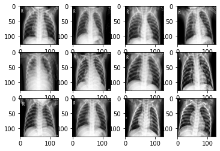

```python
for i in range(12):
  plt.subplot(3,4, i+1)
  plt.imshow(DataTrainImage[i])
```

#### Data Pre-processing: (10Marks)

1. Gaussian Blurring. [Hint: Use kernel size of (5, 5)]
2. Visualize data after performing the Gaussian blurring.
3. Normalization of data

```python
# Normalize the data
Nor_DataTrainImage = DataTrainImage.astype('float32')/255.0 # we need to do one more time during model creation process.
```

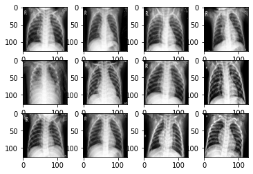

```python
for i in range(12):
  plt.subplot(3,4, i+1)
  plt.imshow(Nor_DataTrainImage[i])
```

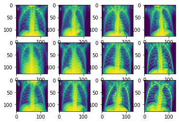

```python
for i in range(12):
  plt.subplot(3,4, i+1)
  plt.imshow(cv2.cvtColor(Nor_DataTrainImage[i],cv2.COLOR_BGR2GRAY)) # Convert image to grayscale just for view
```

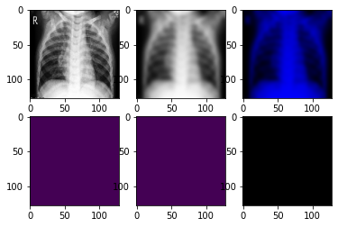

```python
clearTrainImg = []
examples = []; getEx = True
#Here using I am using non normalize image data
for img in DataTrainImage:
    # Use gaussian blur
    #blurImg = cv2.GaussianBlur(img, (5, 5), 0)   #accuracy: 0.6625
    blurImg = cv2.GaussianBlur(img, (15, 15), 0)  #accuracy increase here

    # Convert to HSV image and grayscale image to see which one works better
    hsvImg = cv2.cvtColor(blurImg, cv2.COLOR_BGR2HSV)
   # grayImg = cv2.cvtColor(img, cv2.COLOR_BGR2GRAY)

    # Create mask (parameters - green color range)
    lower_green = (25, 40, 50)
    upper_green = (75, 255, 255)
    mask = cv2.inRange(hsvImg, lower_green, upper_green)
    kernel = cv2.getStructuringElement(cv2.MORPH_ELLIPSE, (11, 11))
    mask = cv2.morphologyEx(mask, cv2.MORPH_CLOSE, kernel)

    # Create bool mask
    bMask = mask > 0

    # Apply the mask
    clear = np.zeros_like(img, np.uint8)  # Create empty image
    clear[bMask] = img[bMask]  # Apply boolean mask to the origin image

    clearTrainImg.append(clear)  # Append image without backgroung

    # Show examples
    if getEx:
        plt.subplot(2, 3, 1); plt.imshow(img)  # Show the original image
        plt.subplot(2, 3, 2); plt.imshow(blurImg)  # Blur image
        plt.subplot(2, 3, 3); plt.imshow(hsvImg)  # HSV image
        #plt.subplot(2, 3, 3); plt.imshow(grayImg)  # Gray image
        plt.subplot(2, 3, 4); plt.imshow(mask)  # Mask
        plt.subplot(2, 3, 5); plt.imshow(bMask)  # Boolean mask
        plt.subplot(2, 3, 6); plt.imshow(clear)  # Image without background
        getEx = False

clearTrainImg = np.asarray(clearTrainImg)
```

[figure not shown]

```python
# Show sample result good to move ahead with clearTrainImg
for i in range(12):
    plt.subplot(3,4, i+1)
    plt.imshow(clearTrainImg[i])
```

```python
blurImg.shape
```

```
(128, 128, 3)
```

```python
clearTrainImg.shape
```

```
(251, 128, 128, 3)
```

[figure not shown]

```python
plt.figure(figsize=(10,10))
for i in range(9):
    plt.subplot(3, 3, i + 1)
    plt.imshow(DataTrainImage[i],cmap='gray')
    plt.title("NORMAL")
plt.show()
```

[figure not shown]

```python
plt.figure(figsize=(10,10))
for i in range(9):
    plt.subplot(3, 3, i + 1)
    plt.imshow(plt.imread(os.path.join(TrianImage + "/PNEUMONIA",Pneumonaimages[i])),cmap='gray')
    plt.title("PNEUMONIA")
plt.show()
```

[figure not shown]

```python
plt.figure(figsize=(10,10))
for i in range(9):
    plt.subplot(3, 3, i + 1)
    plt.imshow(DataTrainImage[i],cmap='gray')
    plt.title("COVID19")
plt.show()
```

#### Make data compatible: (10 Marks)

1. Reshape data into shapes compatible with Keras models.
2. Convert labels to one hot vectors.

```python
#Convert labels to one-hot-vectors.
enc = LabelBinarizer()
clearTrainLabel = enc.fit_transform(DataTrainLabel)
```

```python
clearTrainLabel[0] #Print the label for 1st set, similar y_train[0]
```

```
array([0, 1, 0])
```

```python
#Split the dataset into training, testing, and validation set.
from sklearn.model_selection import train_test_split
x_train, x_test, y_train, y_test = train_test_split(clearTrainImg, clearTrainLabel,test_size=0.3,random_state=seed,stratify = clearTrainLabel)
```

```python
#r split test data into test and validation set with test_size = 0.5
x_test, X_val, y_test, Y_val = train_test_split(x_test,y_test, test_size = 0.5, random_state=seed)
```

```python
print(x_test.shape)
print(X_val.shape)
```

```
(38, 128, 128, 3)
(38, 128, 128, 3)
```

```python
print("X_train shape:", x_train.shape)
print("Images in X_train:", x_train.shape[0])
print("Images in X_test:", x_train.shape[0])
print("Max value in X_train:", x_train.max())
print("Min value in X_train:", x_train.min())
print("Y_train shape:", y_train.shape)
print("Images in Y train:", y_train.shape[0])
print("Images in Y test:", y_train.shape[0])
print("Max value in Y train:", y_train.max())
print("Min value in Y train:", y_train.min())
```

```
X_train shape: (175, 128, 128, 3)
Images in X_train: 175
Images in X_test: 175
Max value in X_train: 0
Min value in X_train: 0
Y_train shape: (175, 3)
Images in Y train: 175
Images in Y test: 175
Max value in Y train: 1
Min value in Y train: 0
```

```python
x_train.shape
```

```
(175, 128, 128, 3)
```

```python
x_test.shape
```

```
(38, 128, 128, 3)
```

```python
y_test.shape
```

```
(38, 3)
```

```python
Y_val.shape
```

```
(38, 3)
```

#### Building CNN: (15 Marks)

1. Define layers.
2. Set optimizer and loss function. (Use Adam optimizer and categorical crossentropy.)

```python
#To avoide overfitting we need to create image generator which will randomly rotate, zoom, shift and flip image during the fitting of the model
from keras.preprocessing.image import ImageDataGenerator
datagen = ImageDataGenerator(
        rotation_range=180,  # randomly rotate images in the range
        zoom_range = 0.1, # Randomly zoom image
        width_shift_range=0.1,  # randomly shift images horizontally
        height_shift_range=0.1,  # randomly shift images vertically
        horizontal_flip=True,  # randomly flip images horizontally
        vertical_flip=True  # randomly flip images vertically
    )
datagen.fit(x_train)
```

```python
# Set the CNN model
model = models.Sequential()
model.add(layers.Conv2D(32, (5, 5), padding='same', activation="relu", input_shape=x_train.shape[1:]))
model.add(layers.BatchNormalization())
model.add(layers.MaxPooling2D((2, 2))) # to downsample the feature maps
model.add(layers.Conv2D(64, (3, 3), activation='relu'))
model.add(layers.BatchNormalization())
model.add(layers.MaxPooling2D((2, 2)))
model.add(layers.Conv2D(128, (3, 3), activation='relu'))
model.add(layers.BatchNormalization())
model.add(layers.MaxPooling2D((2, 2)))
model.add(layers.Conv2D(128, (3, 3), activation='relu'))
model.add(layers.BatchNormalization())
model.add(layers.MaxPooling2D((2, 2)))

# Apply Dropout with 0.2 probability
model.add(layers.Dropout(rate=0.2))
model.add(layers.Conv2D(256, (3, 3), activation='relu'))
model.add(layers.BatchNormalization())
model.add(layers.Dropout(0.5))
model.add(layers.Flatten())
model.add(layers.Dense(256, activation='relu'))
model.add(layers.Dense(12, activation='softmax')) #Check

model.summary()
```

```
Model: "sequential"
_________________________________________________________________
Layer (type)                 Output Shape              Param #
=================================================================
conv2d (Conv2D)              (None, 128, 128, 32)      2432
_________________________________________________________________
batch_normalization (BatchNo (None, 128, 128, 32)      128
_________________________________________________________________
max_pooling2d (MaxPooling2D) (None, 64, 64, 32)        0
_________________________________________________________________
conv2d_1 (Conv2D)            (None, 62, 62, 64)        18496
_________________________________________________________________
batch_normalization_1 (Batch (None, 62, 62, 64)        256
_________________________________________________________________
max_pooling2d_1 (MaxPooling2 (None, 31, 31, 64)        0
_________________________________________________________________
conv2d_2 (Conv2D)            (None, 29, 29, 128)       73856
_________________________________________________________________
batch_normalization_2 (Batch (None, 29, 29, 128)       512
_________________________________________________________________
max_pooling2d_2 (MaxPooling2 (None, 14, 14, 128)       0
_________________________________________________________________
conv2d_3 (Conv2D)            (None, 12, 12, 128)       147584
_________________________________________________________________
batch_normalization_3 (Batch (None, 12, 12, 128)       512
_________________________________________________________________
max_pooling2d_3 (MaxPooling2 (None, 6, 6, 128)         0
_________________________________________________________________
dropout (Dropout)            (None, 6, 6, 128)         0
_________________________________________________________________
conv2d_4 (Conv2D)            (None, 4, 4, 256)         295168
_________________________________________________________________
batch_normalization_4 (Batch (None, 4, 4, 256)         1024
_________________________________________________________________
dropout_1 (Dropout)          (None, 4, 4, 256)         0
_________________________________________________________________
flatten (Flatten)            (None, 4096)              0
_________________________________________________________________
dense (Dense)                (None, 256)               1048832
_________________________________________________________________
dense_1 (Dense)              (None, 12)                3084
=================================================================
Total params: 1,591,884
Trainable params: 1,590,668
Non-trainable params: 1,216
_________________________________________________________________
```

```python
# initiate Adam optimizer
opt = optimizers.Adam(learning_rate=0.001, beta_1=0.9, beta_2=0.999, epsilon=1e-08)
```

```python
#Train the model using RMSprop
model.compile(loss='categorical_crossentropy',
              optimizer=opt,
              metrics=['accuracy'])
```

```python
# Network structure is summarized which confirms our design was implemented correctly. Also doubel check that model looks good.
model.summary()
```

```
Model: "sequential"
_________________________________________________________________
Layer (type)                 Output Shape              Param #
=================================================================
conv2d (Conv2D)              (None, 128, 128, 32)      2432
_________________________________________________________________
batch_normalization (BatchNo (None, 128, 128, 32)      128
_________________________________________________________________
max_pooling2d (MaxPooling2D) (None, 64, 64, 32)        0
_________________________________________________________________
conv2d_1 (Conv2D)            (None, 62, 62, 64)        18496
_________________________________________________________________
batch_normalization_1 (Batch (None, 62, 62, 64)        256
_________________________________________________________________
max_pooling2d_1 (MaxPooling2 (None, 31, 31, 64)        0
_________________________________________________________________
conv2d_2 (Conv2D)            (None, 29, 29, 128)       73856
_________________________________________________________________
batch_normalization_2 (Batch (None, 29, 29, 128)       512
_________________________________________________________________
max_pooling2d_2 (MaxPooling2 (None, 14, 14, 128)       0
_________________________________________________________________
conv2d_3 (Conv2D)            (None, 12, 12, 128)       147584
_________________________________________________________________
batch_normalization_3 (Batch (None, 12, 12, 128)       512
_________________________________________________________________
max_pooling2d_3 (MaxPooling2 (None, 6, 6, 128)         0
_________________________________________________________________
dropout (Dropout)            (None, 6, 6, 128)         0
_________________________________________________________________
conv2d_4 (Conv2D)            (None, 4, 4, 256)         295168
_________________________________________________________________
batch_normalization_4 (Batch (None, 4, 4, 256)         1024
_________________________________________________________________
dropout_1 (Dropout)          (None, 4, 4, 256)         0
_________________________________________________________________
flatten (Flatten)            (None, 4096)              0
_________________________________________________________________
dense (Dense)                (None, 256)               1048832
_________________________________________________________________
dense_1 (Dense)              (None, 12)                3084
=================================================================
Total params: 1,591,884
Trainable params: 1,590,668
Non-trainable params: 1,216
_________________________________________________________________
```

```python
x_train = x_train.astype('float32') # Conversion to float type from integer type.
x_test = x_test.astype('float32')
X_val= X_val.astype(('float32'))
x_train /= 255.0 # Division by 255
x_test /= 255.0
X_val /= 255.0
```

```python
# Use earlystopping stopping callback to the fit function is going to stop the training
#callback = EarlyStopping(monitor='val_loss', patience=20, min_delta=0.01)
early_stopping = EarlyStopping(monitor='val_loss', min_delta=0.01, patience=20)

#Adding Model Checkpoint callback to the fit function is going to save the weights whenever val_loss achieves a new low value.
#Hence saving the best weights occurred during training
checkpoint_filepath = 'weights.{epoch:02d}-{loss:.2f}.hdf5'

#'mak_cnn_checkpoint_{epoch:02d}_loss{val_loss:.4f}.h5'
model_checkpoint_callback =  ModelCheckpoint(checkpoint_filepath,
                                                           monitor='val_loss',
                                                           verbose=1,
                                                           save_best_only=True,
                                                           save_weights_only=True,
                                                           mode='auto',
                                                           save_freq='epoch')
```

```python
#Reshape Date before going to fit
x_train = x_train.reshape(x_train.shape[0], 128, 128, 3)
x_test = x_test.reshape(x_test.shape[0], 128, 128, 3)
X_val=X_val.reshape(X_val.shape[0], 128, 128, 3)

print(x_train.shape)
print(x_test.shape)
print(X_val.shape)
```

```
(175, 128, 128, 3)
(38, 128, 128, 3)
(38, 128, 128, 3)
```

#### Fit and evaluate model and print confusion matrix. (10 Marks)

```python
history = model.fit(datagen.flow(x_train,y_train,batch_size=10),
                    epochs=30,
                    validation_data = (X_val,Y_val),
                    shuffle=True,
                    verbose=1, callbacks=[early_stopping,model_checkpoint_callback]
                   )
```

[output not shown]

```python
# Score Train model.
scores = model.evaluate(x_train, y_train, verbose=1)
print('Train loss:', scores[0])
print('Train accuracy:', scores[1])
```

[output not shown]

```python
scores = model.evaluate(x_test, y_test, verbose=1)
print('Test loss:', scores[0])
print('Test accuracy:', scores[1])
```

[output not shown]

```python
# Score validation model.
scores = model.evaluate(X_val, Y_val, verbose=1)
print('Val loss:', scores[0])
print('Val accuracy:', scores[1])
```

[output not shown]

```python
from sklearn.metrics import confusion_matrix
import itertools

def plot_confusion_matrix(cm, classes,
                          normalize=False,
                          title='Confusion matrix',cmap=plt.cm.Blues):

    fig = plt.figure(figsize=(10,10))
    plt.imshow(cm, interpolation='nearest',cmap=cmap)
    plt.title(title)
    plt.colorbar()
    tick_marks = np.arange(len(classes))
    plt.xticks(tick_marks, classes, rotation=90)
    plt.yticks(tick_marks, classes)

    if normalize:
        cm = cm.astype('float') / cm.sum(axis=1)[:, np.newaxis]

    thresh = cm.max() / 2.
    for i, j in itertools.product(range(cm.shape[0]), range(cm.shape[1])):
        plt.text(j, i, cm[i, j],
                 horizontalalignment="center",
                 color="white" if cm[i, j] > thresh else "black")

    plt.tight_layout()
    plt.ylabel('True label')
    plt.xlabel('Predicted label')

# Predict the values from the validation dataset
predY = model.predict(x_test)
predYClasses = np.argmax(predY, axis = 1)
trueY = np.argmax(y_test, axis = 1)

# confusion matrix
confusionMTX = confusion_matrix(trueY, predYClasses)

# plot the confusion matrix
plot_confusion_matrix(confusionMTX, classes = label_dict)
```

[output not shown]

```python
cv2_imshow(X_test[2])
```

[output not shown]

```python
cv2_imshow(X_test[3])
```

[output not shown]

```python
cv2_imshow(X_test[33])
```

[output not shown]

```python
cv2_imshow(X_test[36])
```

[output not shown]

```python
cv2_imshow(X_test[59])
```

[output not shown]

```python
for i in range(12):
  plt.subplot(3,4, i+1)
  plt.imshow(X_test[i])
```

[output not shown]